# Machine Learning Project

September 17, 2014

### Executive summary

The quantified self movement group collects a wide range of data about their activities using devices such as Jawbone Up, Nike FuelBand, and Fitbit and evaluates how much of an activity they do but not how well. The latter is what this project aims to do. Using data from accelerometers on the belt, forearm, arm, and dumbell of 6 individuals, we predict the way in which a participant did an activity. More information about the project can be found here: http://groupware.les.inf.puc-rio.br/har

### Setup

We first load the training and the test datasets into R.

```r
trainData <- read.csv("pml-training.csv", na.strings = c("",NA))
testData <- read.csv("pml-testing.csv", na.strings = c("",NA))
```

### Exploratory data analysis

The dataset contains 160 variables describing the activity. There are 19622 cases in the training dataset, enough to do cross validation.

```r
c(dim(trainData), dim(testData))
```

```
## [1] 19622   160    20   160
```

### Data cleaning

To create a tidy dataset, we remove the first 6 columns that contain information on the time and date the experiment was conducted as well as on the participant. This information should not correlate with the other measurement data and thus only adds unncecessary information to the model. We also delete columns that contain NAs as they don’t contribute to the model but rather distort it and unnecessarily increase algorithm and time complexity.

```r
names(trainData)[1:6]
```

```
## [1] "X"                    "user_name"            "raw_timestamp_part_1"
## [4] "raw_timestamp_part_2" "cvtd_timestamp"       "new_window"
```

```r
trainNewDF <- subset(trainData, select=-c(1:6))
train <- trainNewDF[colSums(is.na(trainNewDF)) ==0]
testNewDF <- subset(testData, select=-c(1:6))
test <- testNewDF[colSums(is.na(testNewDF)) ==0]
```

### Cross validation

```r
library(caret)
inTrain <- createDataPartition(y=train$classe, p=0.8, list=FALSE)
train <- train[inTrain,]
cv <- train[-inTrain,]
```

### Building and fitting a model

We fit a randomForest model to the data to learn to predict the variable classe, the activity type. This model was chosen because it is very accurate although it might lag in speed and interpretability and tend towards overfitting which we assess in the out of sample and in sample error rate.

```r
library(randomForest)
modelFit <- randomForest(classe ~., data=train)
modelFit
```

```
##
## Call:
##  randomForest(formula = classe ~ ., data = train)
##                Type of random forest: classification
##                      Number of trees: 500
## No. of variables tried at each split: 7
##
##         OOB estimate of  error rate: 0.27%
## Confusion matrix:
##      A    B    C    D    E class.error
## A 4463    1    0    0    0    0.000224
## B    6 3030    2    0    0    0.002633
## C    0    9 2728    1    0    0.003652
## D    0    0   18 2553    2    0.007773
## E    0    0    0    4 2882    0.001386
```

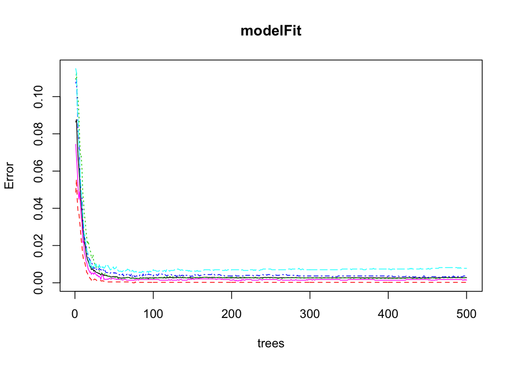

```r
plot(modelFit)
```

### Prediction for the test set

We then apply the model and predict the variable classe in the cross validation, the training set (as a reference to assess the in sample error) and the test set. Below the predictions of the variable class for each of the 20 test cases.

```r
predCV <- predict(modelFit, cv)
predTr <- predict(modelFit, train)
prediction <- predict(modelFit, test)
prediction
```

```
##  1  2  3  4  5  6  7  8  9 10 11 12 13 14 15 16 17 18 19 20
##  B  A  B  A  A  E  D  B  A  A  B  C  B  A  E  E  A  B  B  B
## Levels: A B C D E
```

```r
confusionMatrix(data=predCV, cv$classe)
```

```
## Confusion Matrix and Statistics
##
##           Reference
## Prediction   A   B   C   D   E
##          A 888   0   0   0   0
##          B   0 593   0   0   0
##          C   0   0 542   0   0
##          D   0   0   0 540   0
##          E   0   0   0   0 573
##
## Overall Statistics
##
##                Accuracy : 1
##                  95% CI : (0.999, 1)
##     No Information Rate : 0.283
##     P-Value [Acc > NIR] : <2e-16
##
##                   Kappa : 1
##  Mcnemar's Test P-Value : NA
##
## Statistics by Class:
##
##                      Class: A Class: B Class: C Class: D Class: E
## Sensitivity             1.000    1.000    1.000    1.000    1.000
## Specificity             1.000    1.000    1.000    1.000    1.000
## Pos Pred Value          1.000    1.000    1.000    1.000    1.000
## Neg Pred Value          1.000    1.000    1.000    1.000    1.000
## Prevalence              0.283    0.189    0.173    0.172    0.183
## Detection Rate          0.283    0.189    0.173    0.172    0.183
## Detection Prevalence    0.283    0.189    0.173    0.172    0.183
## Balanced Accuracy       1.000    1.000    1.000    1.000    1.000
```

```r
confusionMatrix(data=predTr, train$classe)
```

```
## Confusion Matrix and Statistics
##
##           Reference
## Prediction    A    B    C    D    E
##          A 4464    0    0    0    0
##          B    0 3038    0    0    0
##          C    0    0 2738    0    0
##          D    0    0    0 2573    0
##          E    0    0    0    0 2886
##
## Overall Statistics
##
##                Accuracy : 1
##                  95% CI : (1, 1)
##     No Information Rate : 0.284
##     P-Value [Acc > NIR] : <2e-16
##
##                   Kappa : 1
##  Mcnemar's Test P-Value : NA
##
## Statistics by Class:
##
##                      Class: A Class: B Class: C Class: D Class: E
## Sensitivity             1.000    1.000    1.000    1.000    1.000
## Specificity             1.000    1.000    1.000    1.000    1.000
## Pos Pred Value          1.000    1.000    1.000    1.000    1.000
## Neg Pred Value          1.000    1.000    1.000    1.000    1.000
## Prevalence              0.284    0.194    0.174    0.164    0.184
## Detection Rate          0.284    0.194    0.174    0.164    0.184
## Detection Prevalence    0.284    0.194    0.174    0.164    0.184
## Balanced Accuracy       1.000    1.000    1.000    1.000    1.000
```

As we don’t have the values for the variable classe in the test set (we are predicting it afterall), we cannot create a confusion matrix between predicted test classe values and actual test classe values. Hence, we cannot assess the out of sample error for the test set.